# Minimum wage and individual worker productivity: Evidence from a large US retailer

Journal of Political Economy, Volume 130, No. 9, September 2022: –

by Desio Coviello, Erika Deserranno, Nicola Persico

2022年08月09日 12:20

# Summary

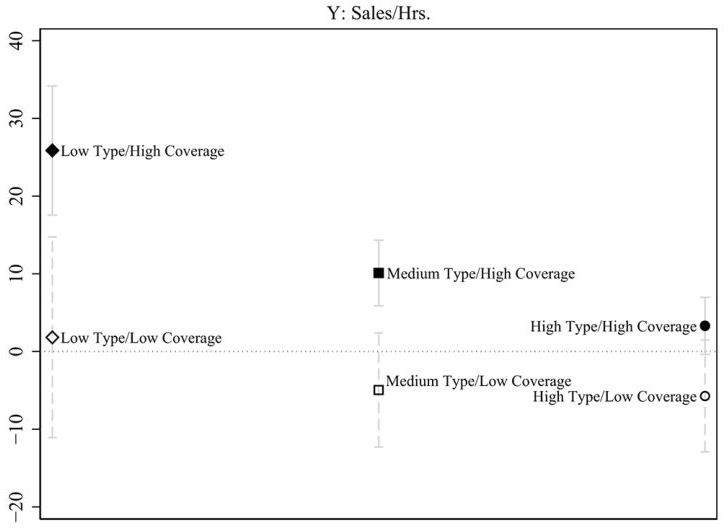

- Minimum wage increases worker productivity at the low end and the centre of the distribution (*low types* and *medium types*), if monitored.
- If not monitored, worker productivity of low and medium types does not increase with MW.
- A sample from a large US wide retailer.
- State border “discontinuity”: Stores in county-pairs (centroids$\leqslant 75$ km apart), with worker and county-pair FEs.
- Workers are supplemented with a gap: MW - actual reward, if positive.
- In theory, MW impacts on worker productivity are two: Efficiency wage ($+$) and reduced incentives ($-$).
- MW increases the value of employment which induces worker efforts, while wage fixing prevents them.
- A model is constructed to show the former is larger for low types under supervision. Low types face a greater probability of being fired, necessitating increased efforts.

# Intro

## Existing literature

**Worker productivity impacts of minimum wages**  
Ku (2022) ($+$, tomato, piece rate), Hill (2018) ($-$, strawberry, piece rate). ID: Contrast low vs. high productivity workers. In this work: Contrast contiguous county stores.

Ku, Hyejin. 2022. “Does Minimum Wage Increase Labor Productivity? Evidence from Piece Rate Workers.” *Journal of Labor Economics* 40 (2): 325–59. https://doi.org/10.1086/716347.

Hill, Alexandra E. 2018. “The Minimum Wage and Productivity: A Case Study of California Strawberry Pickers.” https://alexandraehill.github.io/research/Hill_JMP.pdf.

**Aggregate flow (labour transition) impacts of minimum wages**  
Portugal and Cardoso (2006), Brochu and Green (2013), Dube, Lester, and Reich (2016), Gittings and Schmutte (2016), Jardim et al. (2018). Reduced worker turn overs, lack of disemployment effects in contiguous border pairs at aggregate level. In this work: Store level, similar results.

Portugal, Pedro, and Ana Rute Cardoso. 2006. “Disentangling the minimum wage puzzle: An analysis of worker accessions and separations.” *Journal of the European Economic Association* 4 (5): 988–1013. https://doi.org/10.1162/JEEA.2006.4.5.988.

Brochu, Pierre, and David A. Green. 2013. “The impact of minimum wages on labour market transitions.” *The Economic Journal* 123 (573): 1203–35. https://doi.org/10.1111/ecoj.12032.

Gittings, R. Kaj, and Ian M. Schmutte. 2016. “Getting Handcuffs on an Octopus: Minimum Wages, Employment, and Turnover.” *ILR Review* 69 (5): 1133–70. https://doi.org/10.1177/0019793915623519.

Jardim, Ekaterina, Mark C. Long, Robert Plotnick, Emma Van Inwegen, Jacob Vigdor, and Hilary Wething. 2018. “Minimum Wage Increases and Individual Employment Trajectories.” *National Bureau of Economic Research Working Paper Series* 25182.

**Contiguous border pairs**  
Dube, Lester, and Reich (2010). They use county level data.

Dube, Arindrajit, T. William Lester, and Michael Reich. 2010. “Minimum Wage Effects Across State Borders: Estimates Using Contiguous Counties.” *The Review of Economics and Statistics* 92 (4): 945–64.

**Profit impacts of minimum wages**  
Draca, Machin, and Van Reenen (2011), Riley and Rosazza Bondibene (2017), Harasztosi and Lindner (2019), Hau, Huang, and Wang (2020), Clemens (2021). Nonpositive impacts. In this work: Suggests offsetting effects of increased worker productivity.

Draca, Mirko, Stephen Machin, and John Van Reenen. 2011. “Minimum Wages and Firm Profitability.” *American Economic Journal: Applied Economics* 3 (1): 129–51. https://doi.org/doi:10.1257/app.3.1.129.

Riley, Rebecca, and Chiara Rosazza Bondibene. 2017. “Raising the Standard: Minimum Wages and Firm Productivity.” *Labour Economics* 44: 27–50. https://doi.org/https://doi.org/10.1016/j.labeco.2016.11.010.

Harasztosi, Péter, and Attila Lindner. 2019. “Who Pays for the Minimum Wage?” *American Economic Review* 109 (8): 2693–2727.

Hau, Harald, Yi Huang, and Gewei Wang. 2020. “Firm response to competitive shocks: Evidence from China’s minimum wage policy.” *The Review of Economic Studies* 87 (6): 2639–71. https://doi.org/10.1093/restud/rdz058.

Clemens, Jeffrey. 2021. “How Do Firms Respond to Minimum Wage Increases? Understanding the Relevance of Non-Employment Margins.” *Journal of Economic Perspectives* 35 (1): 51–72.

**Efficiency wage impacts of minimum wages**  
Jayaraman, Ray, and Véricourt (2016) show temporary increases in outputs after increased daily wages in an Indian tea plantation, which contradicts efficiency wages but conforms with gift exchange because workers cannot be fired. Gneezy and List (2006) experiments gift exchange. In this work: Show incentive (efficiency wage) effects of termination. Generalise Rebitzer and Taylor (1995) ’s model.

Jayaraman, Rajshri, Debraj Ray, and Francis de Véricourt. 2016. “Anatomy of a Contract Change.” *American Economic Review* 106 (2): 316–58.

Gneezy, Uri, and John A List. 2006. “Putting Behavioral Economics to Work: Testing for Gift Exchange in Labor Markets Using Field Experiments.” *Econometrica* 74 (5): 1365–84. https://doi.org/https://doi.org/10.1111/j.1468-0262.2006.00707.x.

Rebitzer, James B., and Lowell J. Taylor. 1995. “The Consequences of Minimum Wage Laws Some New Theoretical Ideas.” *Journal of Public Economics* 56 (2): 245–55. https://doi.org/https://doi.org/10.1016/0047-2727(93)01411-3.

## Context

- Company: Hires 10% of national department store employees, 2K stores in all 50 states.
- February 2012 - June 2015: 70 MW increases (state 49, county/city 21).
- Mean MW = 7.87, mean $\Delta$MW = .54.
- 40K+ salespeople $\rightarrow$ 10K salespeople in 200 stores in contiguous county-pair sample.
- Mean pay = USD 1361/month, mean base pay = USD6.12/hour, mean variable pay = USD5.95/unit sales, mean salespeople/store = 16.64, mean turnover/store = 3.4% per month.
- Wage: Mix of fixed wage and piece rate.
- Fair Labor Standards Act: Fill gap = MW - actual wage.
- 42% of workers received gap filling (“MW adjustment”) at least once in 4 weeks.
- Empirical definition of low types: People who were paid MW in $t-1$, or 4% of observations. (Time varying?) Medium types 72.4%, high types 23.7%.
- A USD 1 increase in MW increases “MW adjustment” by USD .25/hour, increases variable pay by USD .44/hour. Shows an endogenous performance increase (Table 2).

# Identification

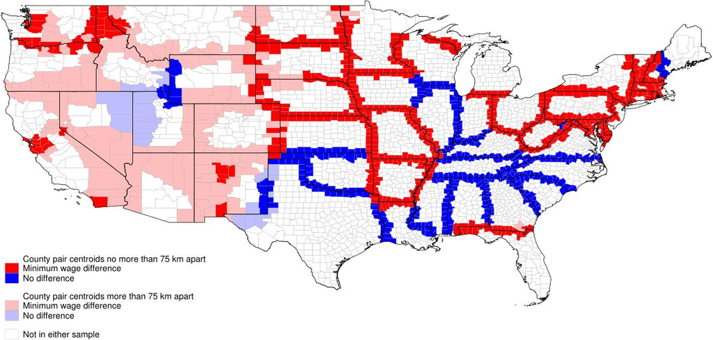

Figure C2: Contiguous county pairs

Border discontinuity design (contiguous county-pair comparisons). Stores located in paired-counties whose centroids are less than 75km apart.

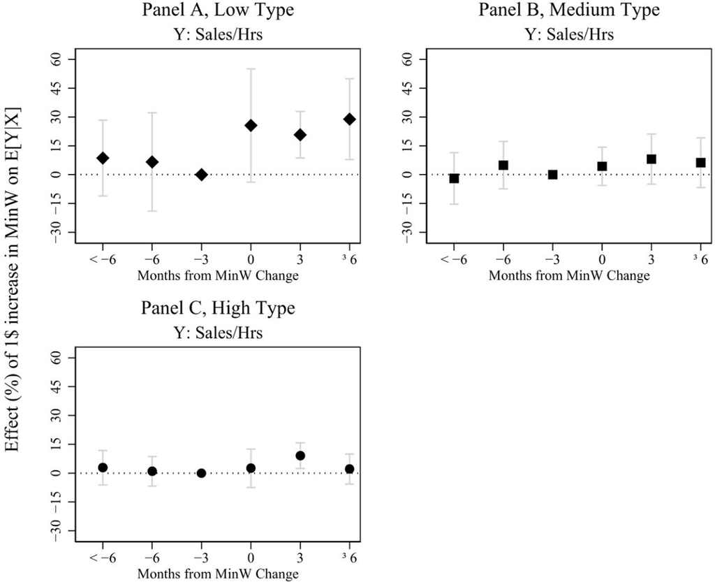

Figure 2: Event study presentation

$$\begin{align}
Y_{ijpt}&=\alpha+\beta \text{MinW}_{jt}+X_{it}\zeta+\eta Z_{jt}+\delta_{i}+\phi_{pt}+\epsilon_{ijpt}.\tag{10}\\
Y_{ijpt}
&=
\beta_{0}+\beta_{1}\text{MinW}_{jt}
+\beta_{2}\text{MediumType}_{ijt}
+\beta_{3}\text{HighType}_{ijt}\\
&\hspace{2.25em}+\beta_{4}\text{MinW}_{jt}\cdot\text{MediumType}_{ijt}
+\beta_{5}\text{MinW}_{jt}\cdot\text{HighType}_{ijt}\tag{11}\\
&\hspace{2.25em}+X_{it}\zeta+\eta Z_{jt}+\delta_{i}+\phi_{pt}+\epsilon_{ijpt}.\\
Y_{ijpt}
&=
\alpha+\sum_{m=-2}^{2}\beta^{3m}_{1}\text{MinW}_{j, t-3*m}
+\gamma_{1}\text{MediumType}_{ijt}
+\gamma_{2}\text{HighType}_{ijt}\\
&\hspace{2.25em}+
\sum_{m=-2}^{2}\beta^{3m}_{2}\text{MinW}_{j, t-3*m}\cdot\text{MediumType}_{ijt}\tag{12}\\
&\hspace{2.25em}+
\sum_{m=-2}^{2}\beta^{3m}_{3}\text{MinW}_{j, t-3*m}\cdot\text{HighType}_{ijt}\\
&\hspace{2.25em}
+X_{it}\zeta+\eta Z_{jt}+\delta_{i}+\phi_{pt}+\epsilon_{ijpt}.
\end{align}$$

“Stacking our data” (multiple use of a single observation): A county bordering $n$ counties can appear $n$ times.

No pre-trend.

# Results

## Core findings

See the figures at the top.

- Increase in sales/hour: 22.6% (low), 8.2% (medium), 2.3% (high, statistically zero).
- Mean increae in sales/hour: 4.5% or elasticity of .35.
- No change in number of workers (Table 6) nor hours worked (Figure 7 or Table F6 shows increased hours for medium and high types … wierd).

## Robustness

No cross border movements.

- Corr[$\Delta$MW, home-to-work distance of new hires] = small (Table E2).
- Home-to-work distance of all workers do not differ across types.

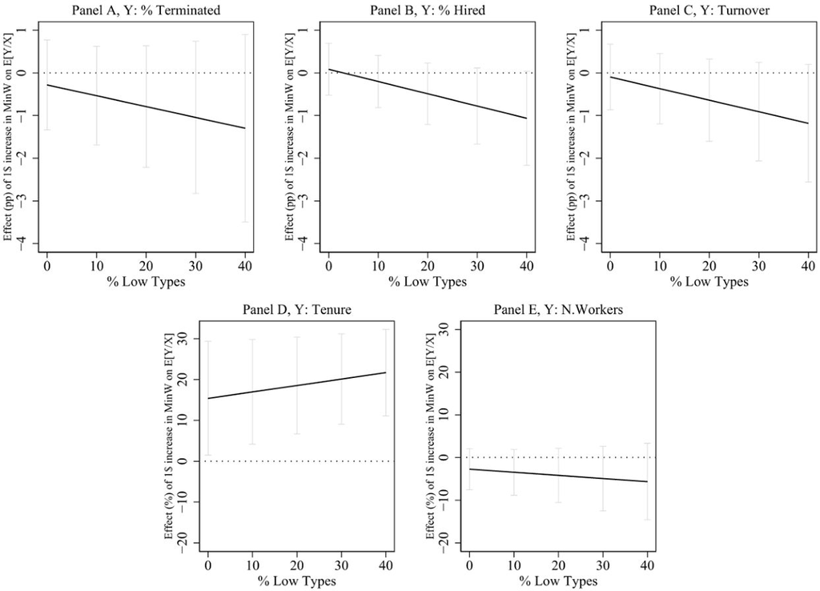

Figure 5: Reduced turnovers for more low types

No worker selection through retention after MW changes.

- Balanced panel shows similar results.
- Bounds for selection bias is small relative to estimates.

Similar results: Alternative cutoff for types, alternative research design using state-level contiguity, alternative border band, unstacking, alternative controls.

Turnovers are reduced and tenure is extended for stores with more low types.

Nationally, store outputs increase but EBITDA (earnings before interest taxes depreciation and amortization) decreases (Table 8). Suggests output increase did not compensate for increased labour costs.

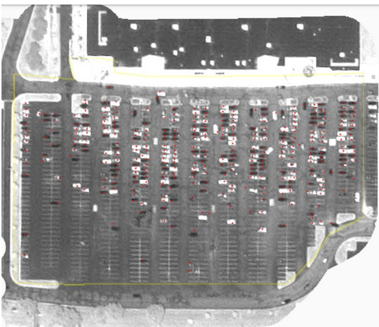

Figure F1: Proxying demand with parking lot occupancy

Demand channel (incidentally increased demand at the time of MW increase, or pass-through on prices which works against increased demand) does not affect the results: Parking lot satellite imagery shows high demand coincides with increased sales of high types. No spillovers: Number of employees as covariate does not change results.

No statistically detectable company response to MW: Allocation of low types to top departments, change hours/month, change ratios of part timers, change benefits/month.

# A model

## Set up and assumptions

Type $x$’s effort $e$ choice problem:
$$V^{E}(x)=\max_{\{e\in[0,1]\}}\;\; w(x, e)-c(x, e)+\frac{1}{1+r}\left[\pi(e)V^{E}(x)+\left\{1-\pi(e)\right\}V^{A}\right].$$

- Expected compensation $w(x, e)=\mathbb{E}\left[\bar{w}\{Y(x, e)\}\right]$ with a stochastic output $Y(x, e)$ and a fixed compensation scheme $\bar{w}(Y)$.
- Probability of employment continuation $\pi(e)$.
- Unemployment value $V^{A}$.
- Random output satisfies monotone likelihood ratio property (MLRP) in $x, e$ $\Rightarrow$ Increasing $x, e$ produces stochastically larger output, or first-order stochastic dominance of output distribution $F_{Y}$.

$\eqref{eq2}$ shows to maxmise current net utility flow $u(x, e)$ and discounted expected net employment value $\frac{1}{1+r}\pi(e)V(x)$. Add $\frac{r}{1+r}V^{E}(x)$ on both sides:
$$\begin{aligned}
V^{E}+\frac{r}{1+r}V^{A}
&=
w-c+\frac{1}{1+r}\pi\left(V^{E}-V^{A}\right)+\left(\frac{1}{1+r}+\frac{r}{1+r}\right)V^{A},\\
\overbrace{V^{E}(x)-V^{A}}^{V(x)}
&=
\overbrace{w(x, e)-c(x, e)-\frac{r}{1+r}V^{A}}^{u(x, e)}+
\frac{1}{1+r}\pi(e)\overbrace{\left(V^{E}(x)-V^{A}\right)}^{V(x)},
\end{aligned}$$
$$\begin{equation}
V(x)
=
\max_{\{e\in[0,1]\}}\;\; u(x, e)+\frac{1}{1+r}\pi(e)V(x).\tag{2}\label{eq2}
\end{equation}$$

$u_{xe}$>0, based on higher types have higher net marginal returns on efforts, is “standard”.

Assumption 2 implies the problem $\eqref{eq2}$ is strictly concave in $e$ so there is an interior solution.

One also needs IRC that the effort set such that $u(x, e)$>0 is nonempty for all $x$.

**Assumption 1**  
$u_{x}>0$, $u_{xe}>0$, $u_{ee}<0$.

**Assumption 2**  
$\pi(e)$ is weakly concave in $e$.

**Assumption 3**  
$\bar{w}(\cdot)$ is strictly increasing in $Y$. $w_{M}(x, 1; M)>0$. $|w_{eM}(x, e; M)|<\infty$.

**Lemma 1**
1. Existence and uniqueness of solution $e^{*}(x)$.
2. $e^{*}(x)$ is nondecreasing in $x$, strictly increasing under the interior solution.
3. If $\pi^{\prime}(e)$ is positive for all $e$, then $e^{*}(x)$ is an interior solution for all $x$. FOC:
$$\begin{equation}
u_{e}(x, e)+\frac{1}{1+r}\pi'(e)V(x)=0.
\tag{4}\label{foc}
\end{equation}$$

## Linking the model to empirical setting

Introducing minimum wages.
$$w(x, e; M)=\mathbb E\left[\max(M, \bar{w}\{Y(x, e)\})\right].$$
$M$ is minimum wage level. Note $w(x, e; M)$ is nondecreasing in all arguments.

**Definition MMW**  
Type $x$ is motivated by minimum wage (MMW) or low type if $w(x, e; M)=M$ for all $e$.

MMW cannot increase wage with $e$, or $w_{e}=0$.

MMW’s only incentive to increase efforts is job security (efficiency wage concerns).

Pure efficiency wage case where everyone is MMW type is inconsistent with data, so ignore this polar case.

Two cases that are nested:

1. Pure pay for performance: $\pi'(e)=0$ or no monitoring. Problem reduces to flow utility maximisation. Efforts come only from performance pay.
2. Hybrid: P4P and efficiency wage: $\pi'(e)>0$ and $M$ is not too high. Low types motivated by efficiency wages only and high types motivated by both efficiency wage and performance pay.

**Proposition 1 (Minimum wage effects on efforts)**

Proof sketch:  
1. FOC in $\eqref{foc}$ is increasing in $M$ for MMW because $w=0$, $c_{eM}=0$ and $V_{M}(x; M)$>0, so optimal effort level must go up when $M$ increases to bring FOC back to zero.  
2. As $M$ increases, $x$ that switches from $e^{*}\uparrow$ to $e^{*}\downarrow$ leads to a contradiction.  
3. $\bar{w}(Y)$ has an upperbound given $Y$ is bounded from above, and for a large enough $M$, expected wage $w(x, e; M)=M$, so everyone becomes MMW. MMW: $M\uparrow$ $\sim$ $e^{*}\uparrow$.  
4. If $\lim\limits_{x\rightarrow\infty} w_{M}(x, e; M)=0$, can show FOC stays zero with a change in $M$, because $V(x; M)$ is a fixed point and $w_{M}=0$ for any $e$.

1. $M\uparrow$ $\sim$ $e^{*}\uparrow$ for MMW (low types) under monitoring.
2. Set of $x$ such that $M\uparrow$ $\sim$ $e^{*}\uparrow$ increases with $M$.
3. For a high enough $M$, $M\uparrow$ $\sim$ $e^{*}\uparrow$ for all $x$.
4. For $x$ whose wage is unaffected by $M$, or high types, $M\uparrow$ $\not\sim$ $e^{*}\uparrow$.

**Proposition 2 (Role of monitoring)**

Proof sketch:
1. $\eqref{eq2}$ gives
$$V(x, e; M)=\frac{1+r}{1+r-\pi(e)}u(x, e; M).$$
By definition, $Q(x, e; M)\equiv \ln V(x, e; M)$ attains its global maximum at $e^{*}$.
$$Q_{e}(x, e; M)=\frac{d}{de}\ln u(x, e; M)+\left[-\frac{d}{de}\ln \{1+r-\pi(e)\}\right].$$
If the second term, elasticity of $1+r-\pi(e)$ with respect to $e$, gets large pointwise, $Q_{e}$ function shifts up in $(Q_{e}, e)$ space, hence the maximiser $e^{*}$ increases.
2. Can show $w_{eM}(x, e; M)$<0 at $e^{*}(x; M)$ so $e^{*}$ must decrease.
3. Envelope theorem gives derivative of maximum value function = derivative of Lagrangian at optimum. So, from $\eqref{eq2}$:
$$\begin{aligned}
V_{M}(x; M)
=
\left.u_{M}(x, e; M)\right|_{e=e^{*}(x; M)}+\frac{1}{1+r}\left.\pi(e)\right|_{e=e^{*}(x; M)}V_{M}(x; M),\\
=
u_{M}\left\{x, e^{*}(x; M); M\right\}+\frac{1}{1+r}\pi\left\{e^{*}(x; M)\right\}V_{M}(x; M),\\
=
\frac{1+r}{1+r-\pi\left\{e^{*}(x; M)\right\}}u_{M}\left\{x, e^{*}(x; M); M\right\}.
\end{aligned}$$
Implict function theorem gives $de=\left\{u_{eM}+\frac{\pi^{\prime}(e)}{1+r}V_{M}(x; M)\right\}dM$, or
$$\frac{de}{dM}=u_{eM}+\frac{\pi^{\prime}(e)}{1+r}V_{M}(x; M)\equiv Q_{eM}(x, e; M).$$
Plug $V_{M}(x; M)$ into the above:
$$\begin{equation}
\left.Q_{eM}(x, e; M)\right|_{e=e^{*}(x; M)}= u_{eM}(x, e; M)\\
\hspace{1em}+\left.\frac{\pi^{\prime}(e)}{1+r-\pi(e)}u_{M}(x, e; M)\right|_{e=e^{*}(x; M)}\\
\geq
\min_{\eta} w_{eM}(x, \eta; M)+\left.\frac{\pi^{\prime}(e)}{1+r-\pi(e)}\right|_{e=e^{*}(x; M)}w_{M}(x, 1; M).
\tag{20}\label{eq20}
\end{equation}$$
If $Q_{eM}(x, e; M)$ is positive at $e^{*}(x; M)$, then $\frac{de}{dM}$>0. This is shown by finiteness of $u_{eM}(x, e; M)=w_{eM}(x, e; M)$ and $u_{M}(x, 1; M)=w_{M}(x, 1; M)$>0 under a large enough $\pi^{\prime}(e)$ so the 2nd term dominates.

1. “Monitoring intensity” $-\frac{d}{de}\ln \{1+r-\pi(e)\} \uparrow$ $\sim$ $e^{*}\uparrow$ for all $x$.
2. If $\pi'(e)=0$, $e^{*}=0$ for MMW and $M\uparrow$ $\sim$ $e^{*}\downarrow$ for non MMW.
3. Under sufficiently intense monitoring $\pi'(e)$, $M\uparrow$ $\sim$ $e^{*}\uparrow$ for all $x$.

Prop 2.2 says: Under no monitoring, as MW increases, MMW do not change efforts while high types reduce them.  
Prop 2.3 says: Under close monitoring, as MW increases, all types increase efforts.

**Proposition 3 (Minimum wage effects on turnover)**  
$M\uparrow$ $\sim$ worker inflow $\lambda\downarrow$

**Lemma 2 (Minimum wage effects on profits)**  
$M\uparrow$ cannot increase nationwide profits.

# 感想

- なるほど: 伝統的な労働経済学理論を最低賃金の効果に重ね合わせた
- 最低賃金を利用して理論の検定をしたような印象、最低賃金臭が薄い
- 人事+売上情報の優位性: 生産性データを賃金情報と対照
- 直感に合致する理論を稀少データによって判定: 監視下のLow typesには効率賃金効果が誘因削減効果を上回る
- 「成果報酬があっても効率賃金効果の説明力が高い」
- 実証だけでもfull empirical paperだが、理論も簡易に留めながら必要な結果を厳密に出す、3人だけど仕事量が多い
- 分量としても順番にしても理論が主のように書かれているので、読み始めは面白味がない気がしたが、読後は実証の知見に面白さを感じた
- 最低賃金の効果: 今までは労働需要側の対応が多かったが、労働供給側のon-the-job対応は知見が少なかった
- On-the-job対応はサーチ理論にも影響を与えそう
- 雇用効果のintensive margin: 雇用は減らないし、労働時間は変わらない(medium, highは増えている)し、パートタイマーも増えない
- 労働生産性の上昇は労働費用増加を帳消しにしないので利潤低下
- なので、雇用効果のextensive marginは負になりそうだが、calibrationでは失業者の厚生も増加
- 外的妥当性: 「より小規模企業の方が賃金体系を操作しやすいので影響は少ないだろう」「集計量と企業特性が似ている」「他企業では努力の他労働者への波及があり得る」
- 「最低賃金引き上げに対応するために企業は労働生産性を高めねばならない」「労働生産性を高めるためには人的資本投資、リスキリングが…」=日経新聞の十八番
- (労働者の努力の範囲内ならば)自動的に労働生産性が高まる可能性を示した
- 結果はアメリカの労働者だから納得いくが、日本の労働者はすでに相当の努力をしていそう
- 途上国でも対象労働者が貧しい(=もともと生産性が低い)ほど似た結果になりそうだけど、解雇不能なインド茶農園では贈り物交換ぽい結果